# Task14

Tomas Kozlovskis

2016 m gegužė 13 d

## TASK 14

### 1. For the wmurders data:

#### (a) If necessary, find a suitable Box-Cox transformation for the data

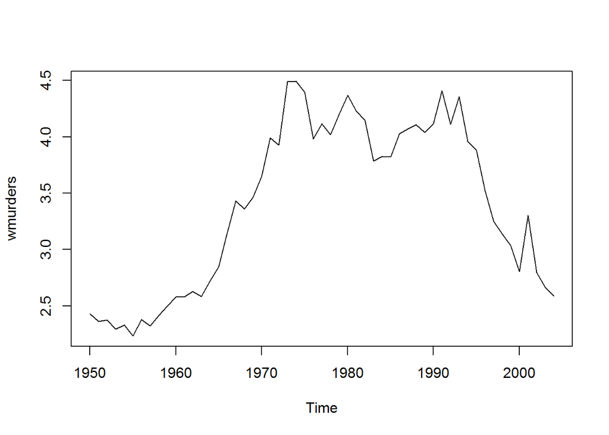

There is no clear cyclicity or trend in the data given. We can try to apply Box-Cox transformation in order to acquire more normal and stable dataset.

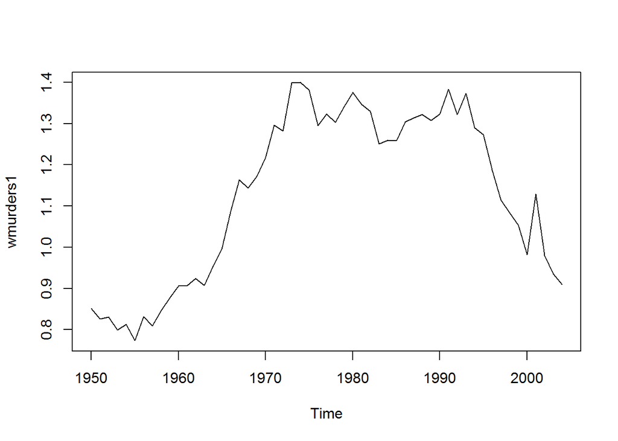

Box-Cox transformation is not useful, because it does not give more normal or less fluctuating data.

In order to choose the order for ARIMA model, we have to make series stationary. We will be using differencing in order to obtain stationary data.

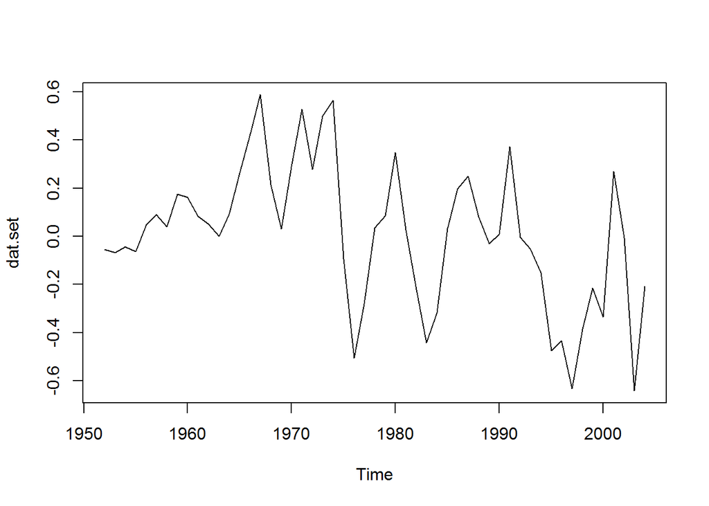

```r
dat.set<-diff(wmurders, ndiffs(wmurders))
plot(dat.set)
```

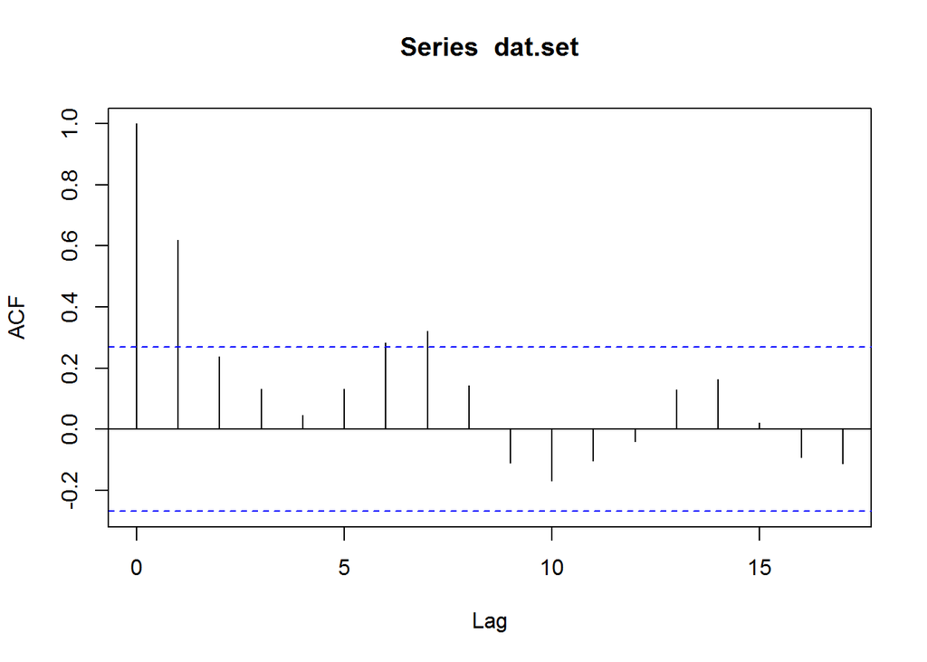

```r
acf(dat.set)
```

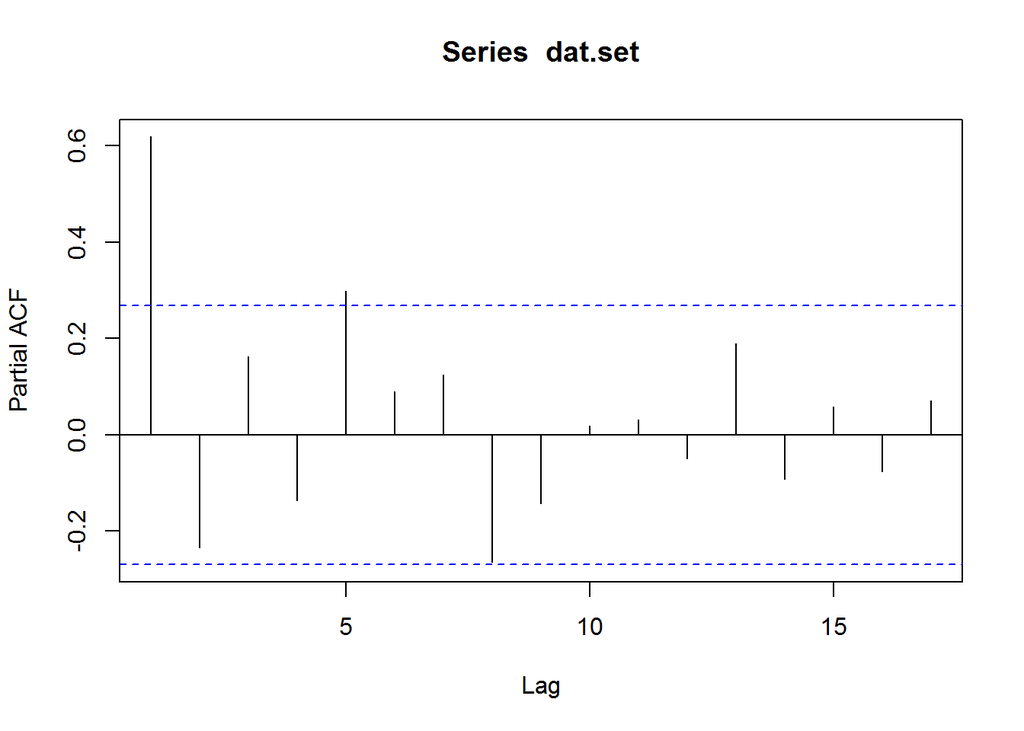

```r
pacf(dat.set)
```

The data now looks like stationary.

```r
adf.test(dat.set)
```

```
##
##  Augmented Dickey-Fuller Test
##
## data:  dat.set
## Dickey-Fuller = -3.9819, Lag order = 3, p-value = 0.01705
## alternative hypothesis: stationary
```

$adf.test$ gives a value lower than 0.05, which means that we can accept the alternative hypothesis which states that data is stationary.

#### (b) Fit a suitable ARIMA model to the transformed data using auto.arima()

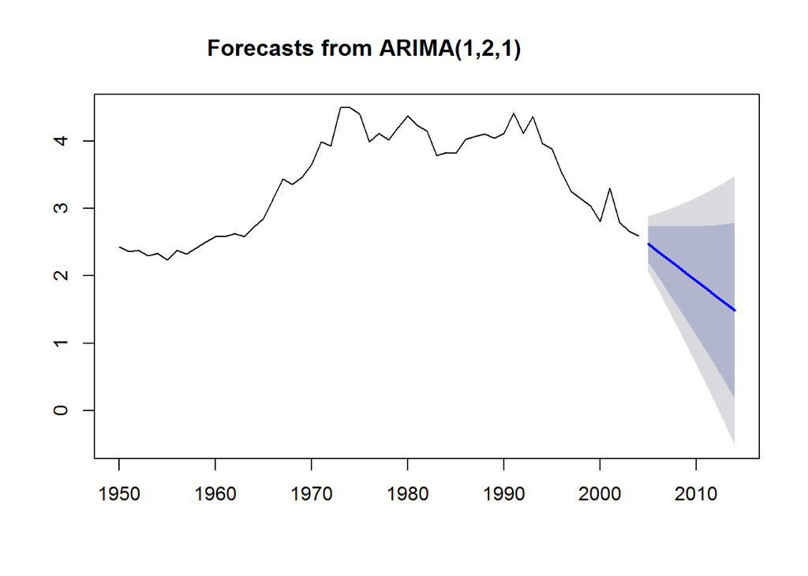

```r
fit.auto<-auto.arima(wmurders)
plot(forecast(fit.auto,h=10),include=80)
```

```r
AIC(fit.auto)
```

```
## [1] -6.879768
```

Looks like the forecast using $auto.arima$ is highly influenced by drop of female murders from 1990 until 2004.

#### (c) Try some other plausible models by experimenting with the orders chosen

```r
fit.1<-arima(wmurders, order=c(5,2,0))
AIC(fit.1)
```

```
## [1] -3.772489
```

```r
fit.2<-arima(wmurders, order=c(0,2,3))
AIC(fit.2)
```

```
## [1] -7.535907
```

```r
fit.3<-arima(wmurders, order=c(2,2,4))
AIC(fit.3)
```

```
## [1] -8.572519
```

#### (d) Choose what you think is the best model and check the residual diagnostics

We are choosing model $fit.3$, because it’s AIC is the lowest. We have to check if model’s residuals look like white noise.

```r
mean(fit.res)
```

```
## [1] -0.01093594
```

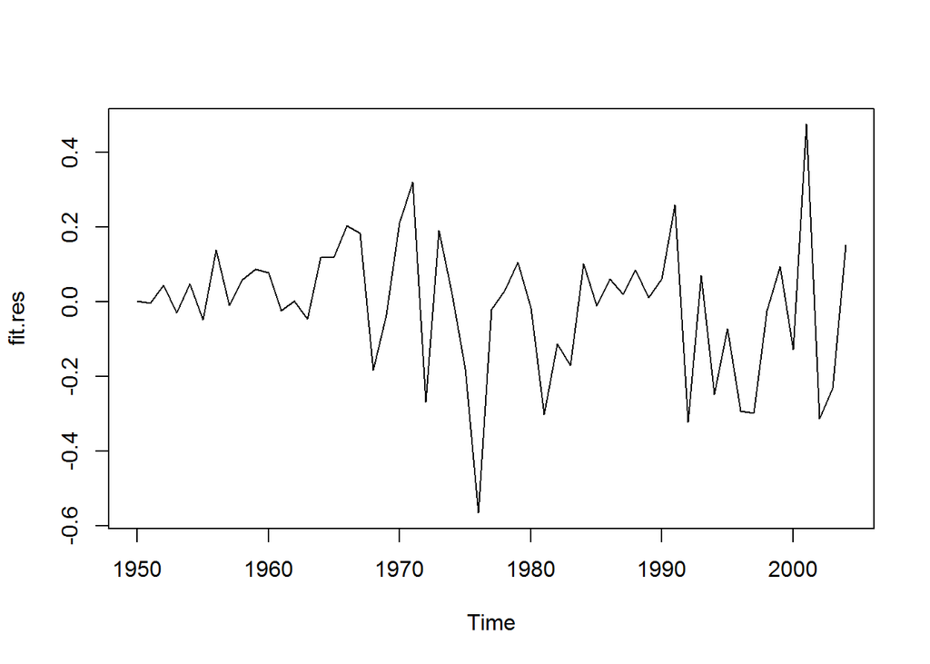

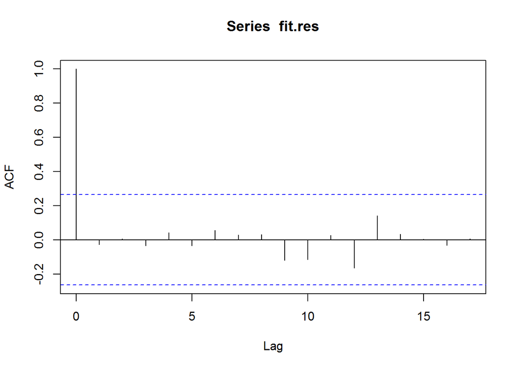

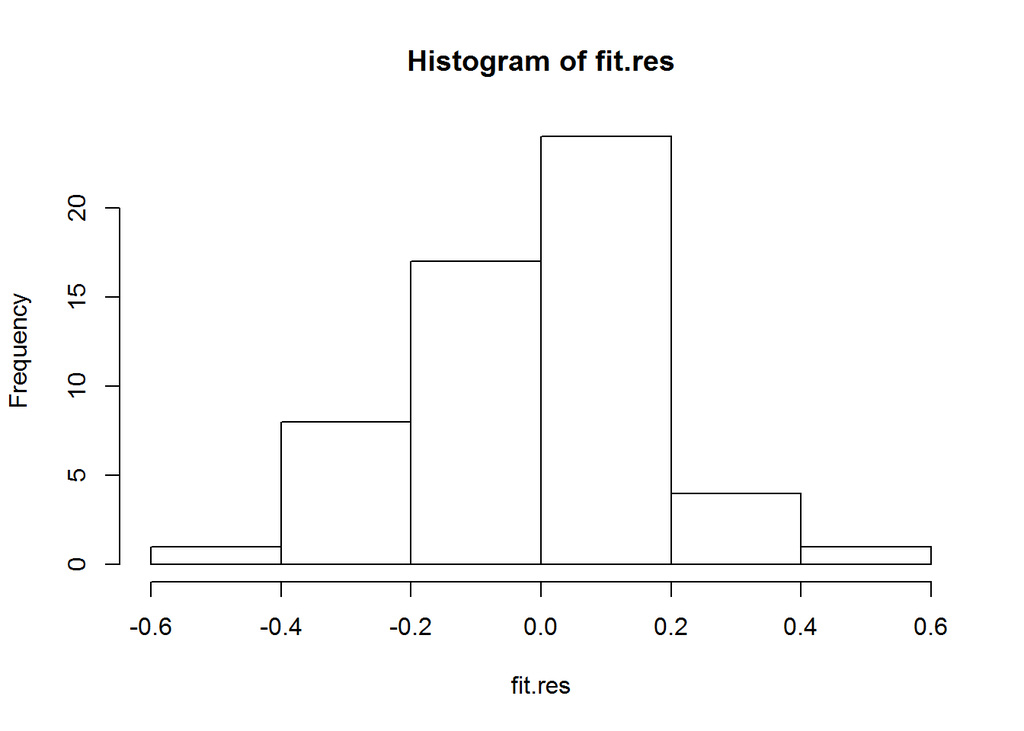

Residuals look like they are white noise - their mean is close to zero and their ACF graph shows that there is no autocorrelation.

```r
shapiro.test(fit.res)
```

```
##
##  Shapiro-Wilk normality test
##
## data:  fit.res
## W = 0.9638, p-value = 0.09619
```

Shapiro-Wilk test gives a p-value higher than 0.05, so we can accept null hypothesis which states that residuals are normal.

```r
adf.test(fit.res)
```

```
##
##  Augmented Dickey-Fuller Test
##
## data:  fit.res
## Dickey-Fuller = -3.6463, Lag order = 3, p-value = 0.03741
## alternative hypothesis: stationary
```

Model’s residuals are actually a white noise, $adf.test$ gives p-value lower than 0.05, which means that we have to accept alternative hypothesis, that series is stationary.

#### (e) Produce forecasts of your fitted model. Do the forecasts look reasonable?

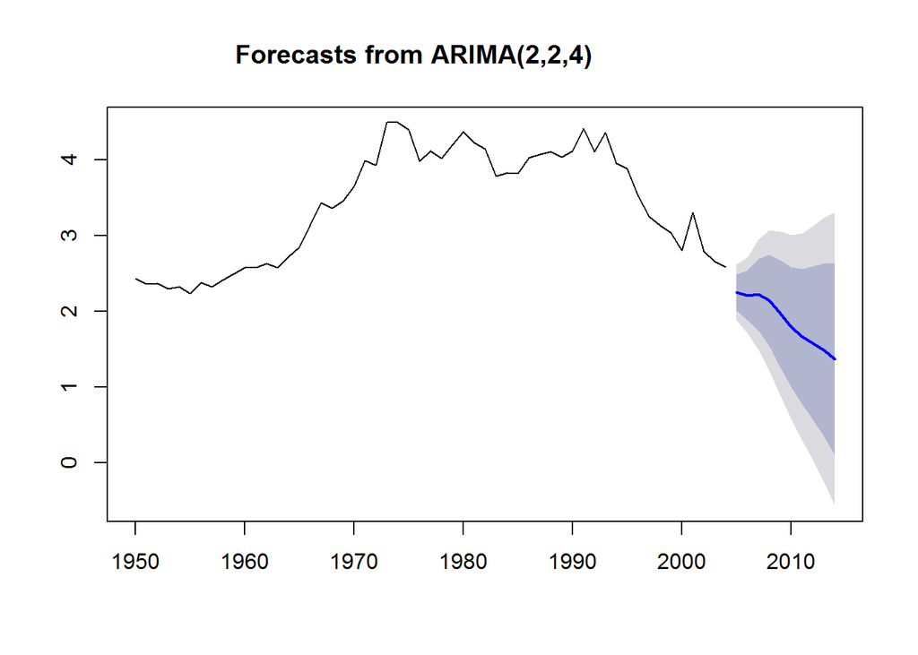

#### (f) Compare the results with what you would obtain using ets()(with no transformation).

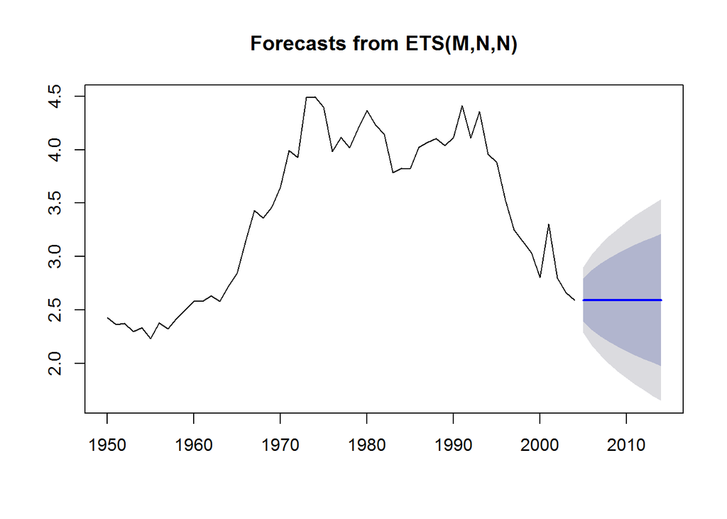

```r
accuracy(fit.3)
```

```
##                       ME      RMSE       MAE       MPE     MAPE     MASE
## Training set -0.01093594 0.1810643 0.1327383 -0.220265 3.865144 0.816278
##                     ACF1
## Training set -0.02801252
```

```r
accuracy(fit.4)
```

```
##                       ME      RMSE       MAE         MPE     MAPE
## Training set 0.003312256 0.2112237 0.1601015 -0.05566248 4.653734
##                   MASE        ACF1
## Training set 0.9845492 -0.03394939
```

Forecast of $fit.3$ gives smaller errors, so it is better than forecast using ETS.

### 2. For the usgdp data:

#### (a) If necessary, find a suitable Box-Cox transformation for the data

Firstly, let’s have a look at our time series. We have quartely US GDP data from 1947 until 2006.

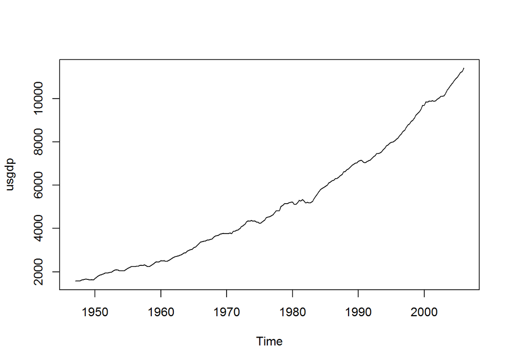

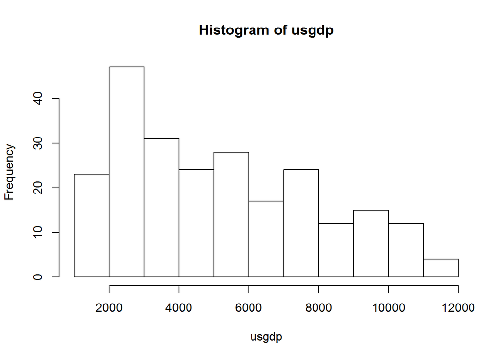

There is a clear trend in the data given. We can try to apply Box-Cox transformation in order to acquire more normal and stable dataset.

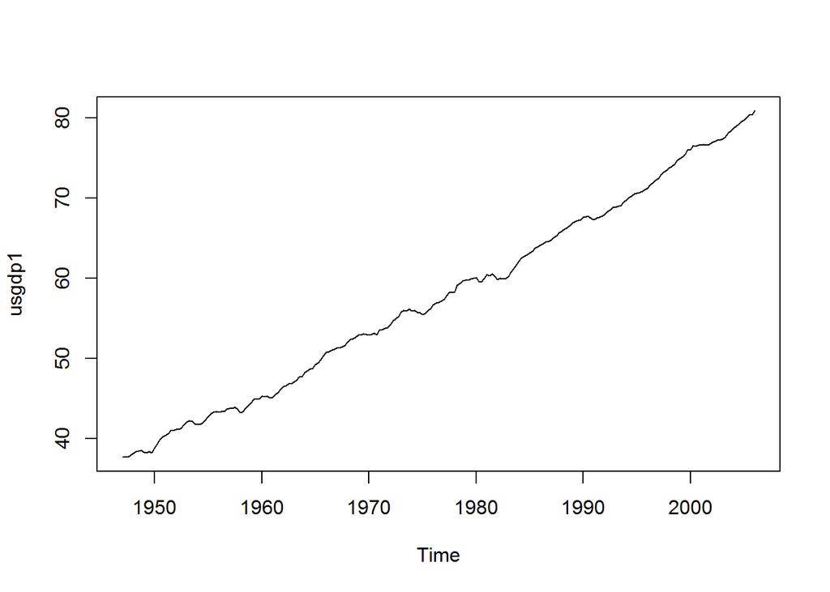

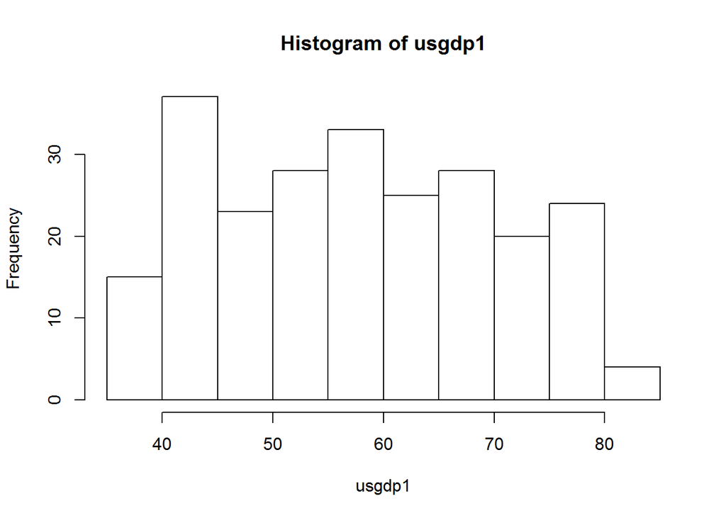

Box-Cox transformation is useful, because it gives slightly more balanced and normal data.

In order to choose the order for ARIMA model, we have to make series stationary. We will be using differencing in order to obtain stationary data.

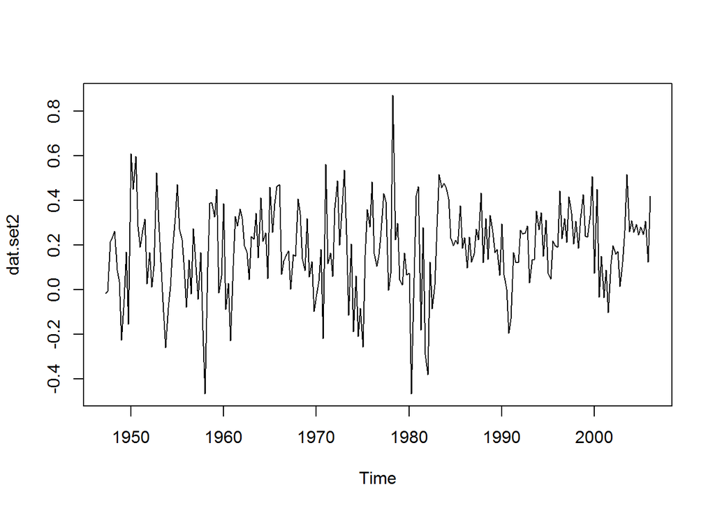

```r
dat.set2<-diff(usgdp1, ndiffs(usgdp1))
plot(dat.set2)
```

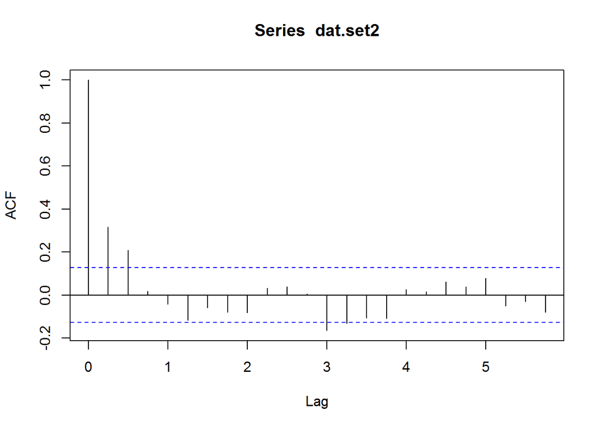

```r
acf(dat.set2)
```

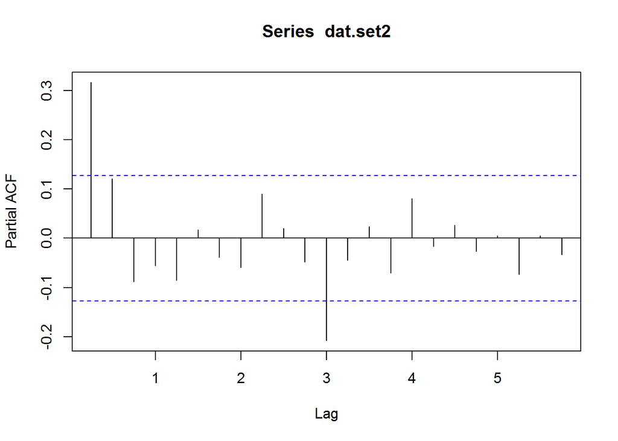

```r
pacf(dat.set2)
```

The data now looks like stationary.

```r
adf.test(dat.set2)
```

```
##
##  Augmented Dickey-Fuller Test
##
## data:  dat.set2
## Dickey-Fuller = -6.0828, Lag order = 6, p-value = 0.01
## alternative hypothesis: stationary
```

$adf.test$ gives a value lower than 0.05, which means that we have to accept alternative hypothesis which states that data is stationary.

#### (b) Fit a suitable ARIMA model to the transformed data using auto.arima()

```r
fit.auto.2<-auto.arima(usgdp1)
AIC(fit.auto.2)
```

```
## [1] -114.5894
```

#### (c) Try some other plausible models by experimenting with the orders chosen

```r
fit.1.2<-arima(usgdp1, order=c(12,1,0))
AIC(fit.1.2)
```

```
## [1] -89.88588
```

```r
fit.2.2<-arima(usgdp1, order=c(0,1,2))
AIC(fit.2.2)
```

```
## [1] -46.38248
```

```r
fit.3.2<-arima(usgdp1, order=c(14,1,2))
AIC(fit.3.2)
```

```
## [1] -105.5483
```

#### (d) Choose what you think is the best model and check the residual diagnostics

We are choosing model $fit.auto.2$, because it’s AIC is the lowest. We have to check if residuals look like white noise.

```r
mean(fit.res.2)
```

```
## [1] 0.0006791305
```

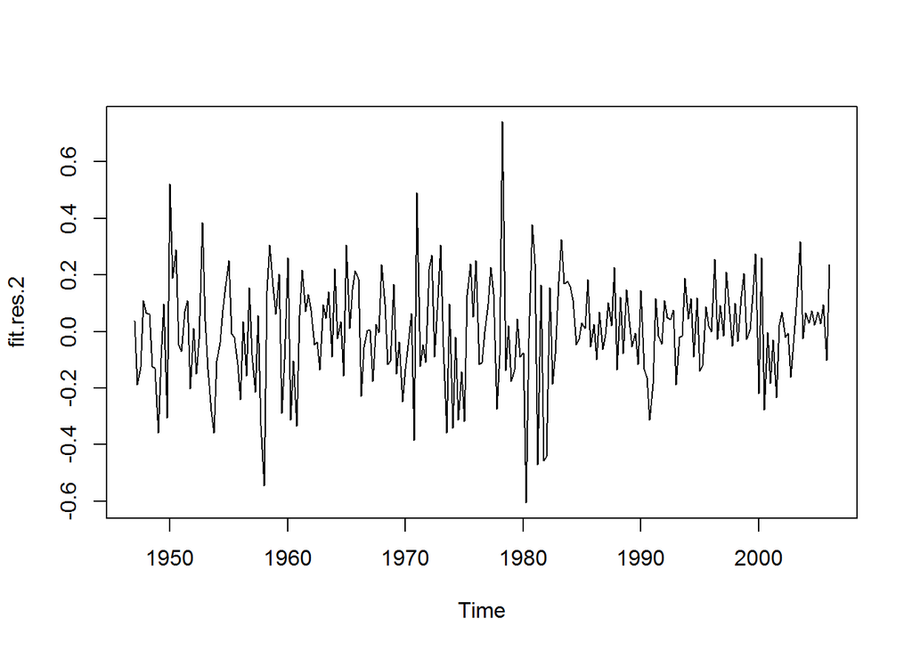

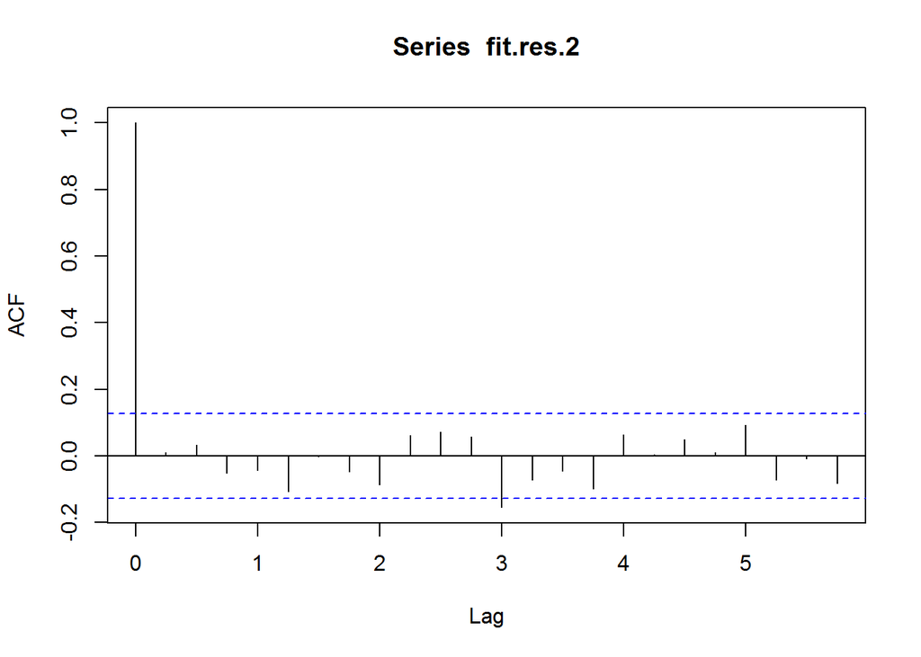

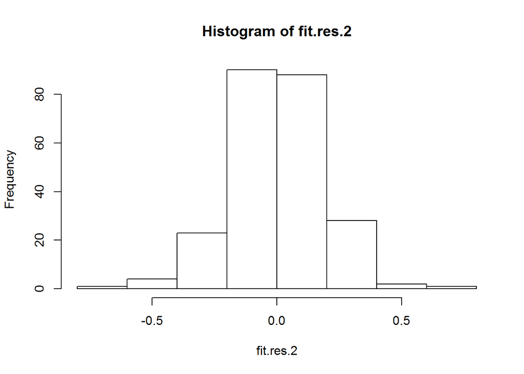

```r
adf.test(fit.res.2)
```

```
##
##  Augmented Dickey-Fuller Test
##
## data:  fit.res.2
## Dickey-Fuller = -6.6688, Lag order = 6, p-value = 0.01
## alternative hypothesis: stationary
```

Model’s residuals are actually a white noise, $adf.test$ gives p-value lower than 0.05, which means that we have to accept alternative hypothesis, which states that series is stationary.

#### (e) Produce forecasts of your fitted model. Do the forecasts look reasonable?

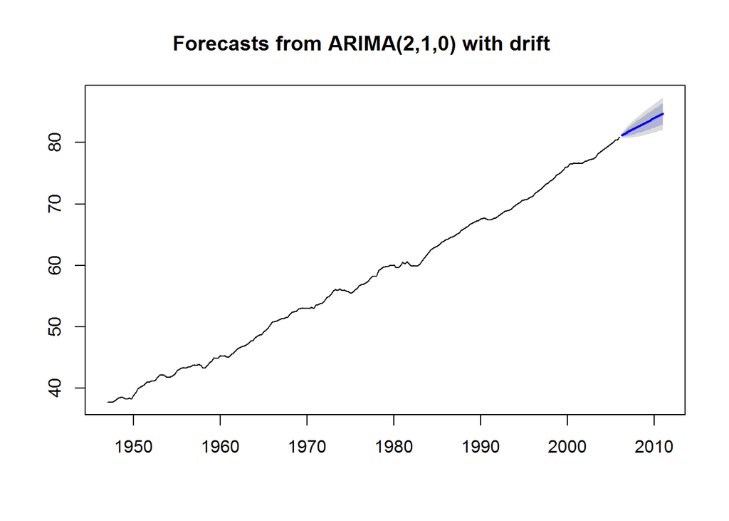

#### (f) Compare the results with what you would obtain using ets()(with no transformation).

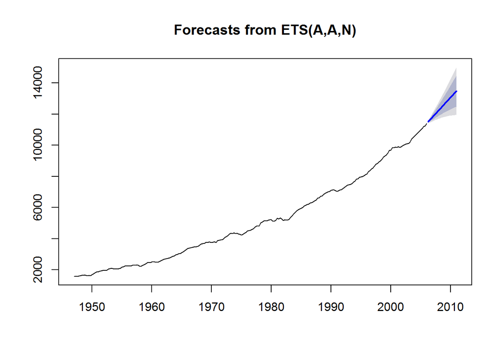

```r
accuracy(fit.auto.2)
```

```
##                        ME      RMSE       MAE          MPE     MAPE
## Training set 0.0006791305 0.1859861 0.1417489 -0.004468837 0.264737
##                   MASE        ACF1
## Training set 0.1789208 0.009570738
```

```r
accuracy(fit.4.2)
```

```
##                    ME     RMSE      MAE        MPE      MAPE      MASE
## Training set 1.424398 41.52588 31.80149 0.03078965 0.7510978 0.1797335
##                    ACF1
## Training set 0.07600545
```

Forecast of $fit.auto.2$ gives smaller errors, so it is better than forecast using ETS.

### 3. For the mcopper data:

#### (a) If necessary, find a suitable Box-Cox transformation for the data

Firstly, let’s have a look at our time series. We have monthly copper prices of time series format.

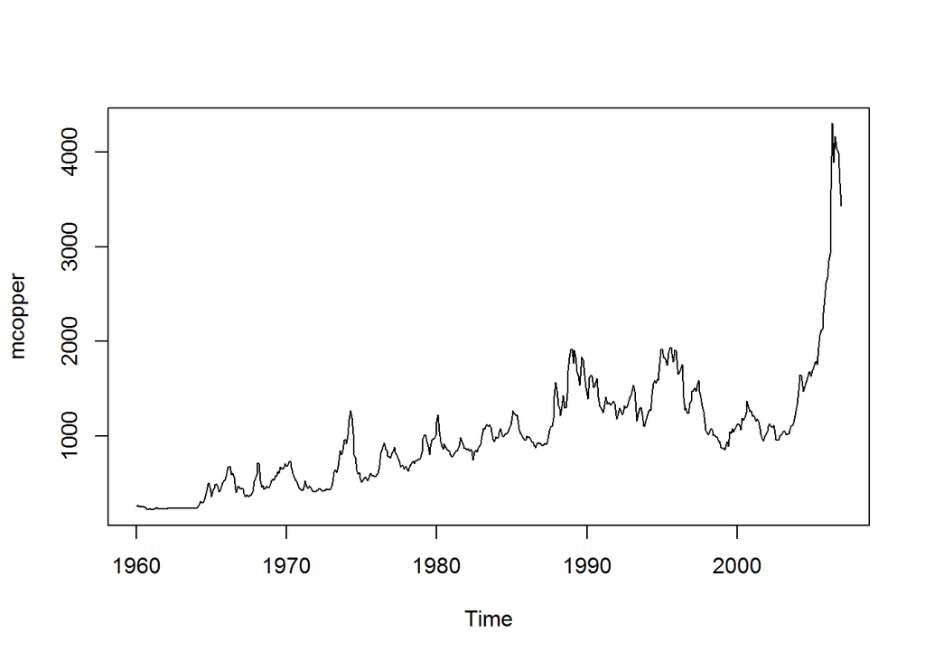

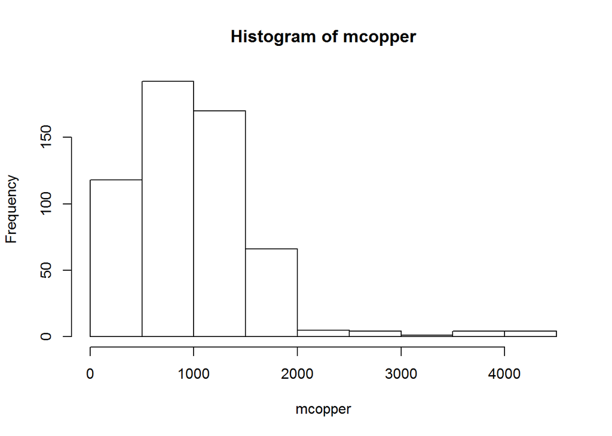

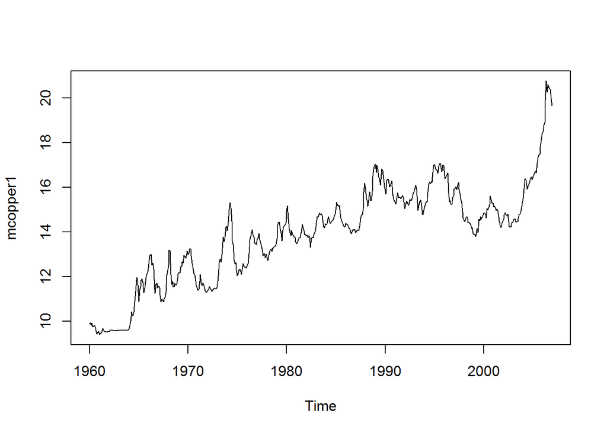

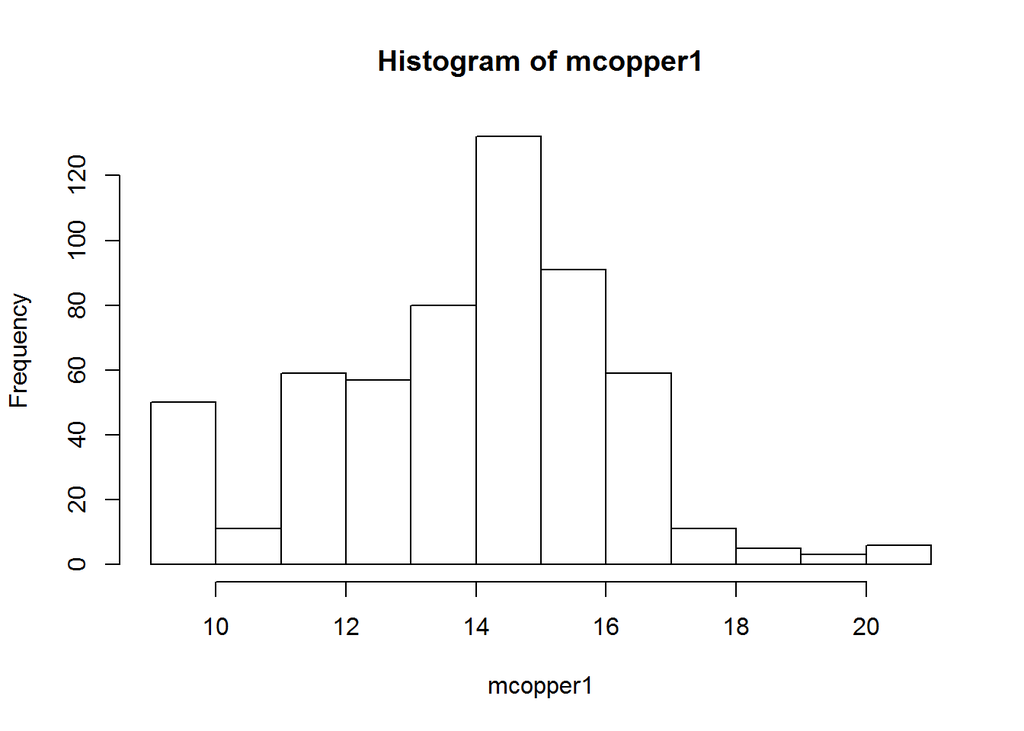

Box-Cox transformation is useful, time series looks more balanced and normal now.

In order to choose the order for ARIMA model, we have to make series stationary. We will be using differencing in order to obtain stationary data.

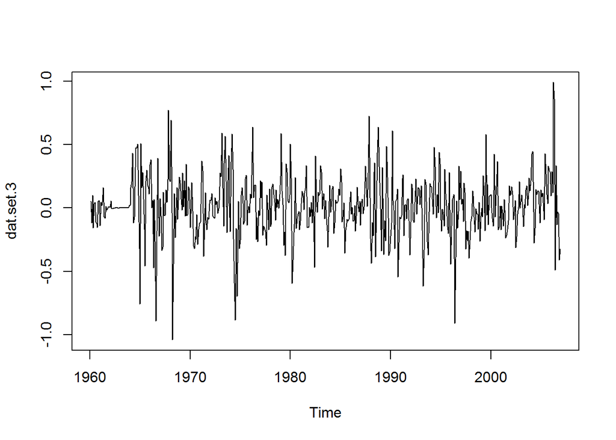

```r
dat.set.3<-diff(mcopper1, ndiffs(mcopper1))
plot(dat.set.3)
```

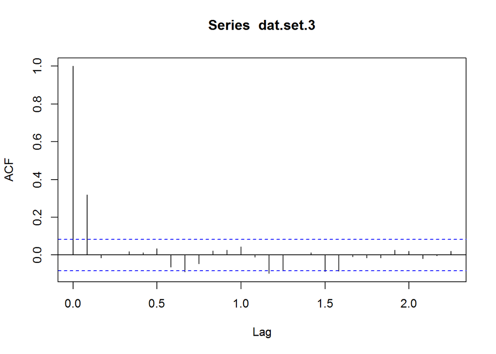

```r
acf(dat.set.3)
```

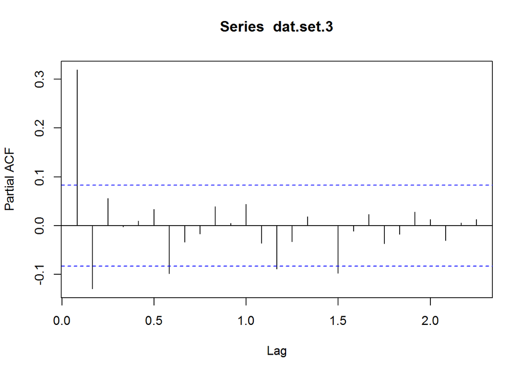

```r
pacf(dat.set.3)
```

The data now looks like stationary.

```r
adf.test(dat.set.3)
```

```
##
##  Augmented Dickey-Fuller Test
##
## data:  dat.set.3
## Dickey-Fuller = -8.2555, Lag order = 8, p-value = 0.01
## alternative hypothesis: stationary
```

$adf.test$ gives a value lower than 0.05, which means that we accept alternative hypothesis which states that data is stationary.

#### (b) Fit a suitable ARIMA model to the transformed data using auto.arima()

```r
fit.auto.3<-auto.arima(mcopper1)
AIC(fit.auto.3)
```

```
## [1] -86.0969
```